# GCDS Homework #03

KEY

Due: 09-22-2022

For this homework, you will save the `R Markdown` homework document and save it to “GCDS/r” on your computer. Rename as **“GCDS_HW_03_yourname”**. When you open it, add your name to the author part of the YAML code. The homework will need to be submitted as a `knit` HTML file. Feel free to work with a partner but understand that the work submitted has to be your own.

- `select()`: for selecting variables
- `mutate()`: for creating/modifying variables
- `arrange()`: for arranging the data frame by variable(s)
- `filter()`: for filtering cases/rows
- `group_by()`: for grouping by variable levels
- `summarise()`: for summarizing statistics

**Questions:**

If you collaborated with any peers, add their names here:

# 1 Load `dplyr`, `ggplot2`, `magrittr` libraries

```r
library(dplyr)
```

```r
library(ggplot2)
library(magrittr)
```

# 2 **Read Data**

Download “Games_Survey_numeric_cleaned.csv” from Slack #data, save, and read in data file and assign to object.

```r
dat_file_path <- paste(data_dir,
                       "Games_Survey_numeric_cleaned.csv",
                       sep = "/")
GAME_DAT <- readr::read_csv(dat_file_path)
```

Much of the homework involves selecting variables, which can be done easily using functions from the `dplyr` library.

If you get stuck, you can review notes or also `?select` to find held and read the docs on what `select()` can do and what helper functions you can use to help with selecting variables.

# 3 **Select variables from a data frame with and without `magrittr`**

This question is designed to provide you with practice using `dplyr`’s verb functions on their own or in conjunction with piping operators like `magrittr`s `%>%`. Remember that either way, the first argument you are passing will be a data frame.

## 3.1 *Select variables by names matching patterns*

First, take your data frame and select variables *start with* a character string of your choosing without using `%>%`

Second, do the same but in conjunction with `%>%`

```r
# check names for patterns head(GAME_DAT)


select(GAME_DAT, starts_with("mech"))
```

```
## # A tibble: 38 × 42
##    mechanic-ac…¹ mecha…² mecha…³ mecha…⁴ mecha…⁵ mecha…⁶ mecha…⁷ mecha…⁸ mecha…⁹
##            <dbl>   <dbl>   <dbl>   <dbl>   <dbl>   <dbl>   <dbl>   <dbl>   <dbl>
##  1             3       3       7       7       7       3       3       3       7
##  2             2       7       1       1       3       1       1       1       3
##  3             1       7       1       3       3       1       1       1       1
##  4             2       2       3       3       2       3       2       3       7
##  5             1       1       7       7       1       3       3       7       1
##  6             1       1       2       1       1       1       1       1       1
##  7             2       7       1       7       1       1       1       1       1
##  8             1       1       1       1       1       3       1       1       1
##  9             2       7       1       1       1       1       1       1       1
## 10             1       7       7       7       1       1       1       1       1
## # … with 28 more rows, 33 more variables:
## #   `mechanic-commodity speculation` <dbl>, `mechanic-competition` <dbl>,
## #   `mechanic-competitive maneuvers` <dbl>, `mechanic-co-operative play` <dbl>,
## #   `mechanic-dice rolling` <dbl>, `mechanic-grid movement` <dbl>,
## #   `mechanic-hand management` <dbl>, `mechanic-drawing` <dbl>,
## #   `mechanic-memory` <dbl>, `mechanic-paper-and-pencil` <dbl>,
## #   `mechanic-partnerships` <dbl>, `mechanic-pattern building` <dbl>, …
```

```r
# with magrittr
GAME_DAT %>%
  select(., starts_with("mech"))
```

```
## # A tibble: 38 × 42
##    mechanic-ac…¹ mecha…² mecha…³ mecha…⁴ mecha…⁵ mecha…⁶ mecha…⁷ mecha…⁸ mecha…⁹
##            <dbl>   <dbl>   <dbl>   <dbl>   <dbl>   <dbl>   <dbl>   <dbl>   <dbl>
##  1             3       3       7       7       7       3       3       3       7
##  2             2       7       1       1       3       1       1       1       3
##  3             1       7       1       3       3       1       1       1       1
##  4             2       2       3       3       2       3       2       3       7
##  5             1       1       7       7       1       3       3       7       1
##  6             1       1       2       1       1       1       1       1       1
##  7             2       7       1       7       1       1       1       1       1
##  8             1       1       1       1       1       3       1       1       1
##  9             2       7       1       1       1       1       1       1       1
## 10             1       7       7       7       1       1       1       1       1
## # … with 28 more rows, 33 more variables:
## #   `mechanic-commodity speculation` <dbl>, `mechanic-competition` <dbl>,
## #   `mechanic-competitive maneuvers` <dbl>, `mechanic-co-operative play` <dbl>,
## #   `mechanic-dice rolling` <dbl>, `mechanic-grid movement` <dbl>,
## #   `mechanic-hand management` <dbl>, `mechanic-drawing` <dbl>,
## #   `mechanic-memory` <dbl>, `mechanic-paper-and-pencil` <dbl>,
## #   `mechanic-partnerships` <dbl>, `mechanic-pattern building` <dbl>, …
```

## 3.2 *Select numeric variables*

In conjunction with `%>%`, take your data frame and select variables that are numeric while piping using `magrittr`

```r
GAME_DAT %>%
  select(., where(is.numeric))
```

```
## # A tibble: 38 × 163
##    enjoy chall…¹ enjoy…² enjoy…³ enjoy…⁴ most …⁵ chara…⁶ chara…⁷ chara…⁸ chara…⁹
##            <dbl>   <dbl>   <dbl>   <dbl>   <dbl>   <dbl>   <dbl>   <dbl>   <dbl>
##  1             1       1       2       1       1       1       1       2       1
##  2             1       1       2       1       4       1       1       1       1
##  3             2       2       1       1       4       1       1       1       1
##  4             1       1       3       2       1       1       1       1       2
##  5             1       2       1       2       3       1       1       1       1
##  6             1       3       1       1       4       1       1       1       1
##  7             1       1       1       1       3       1       1       1       1
##  8             1       1       1       1       3       1       1       2       2
##  9             1       1       1       1       4       1       1       1       1
## 10             1       2       1       1       3       1       1       2       1
## # … with 28 more rows, 154 more variables: `characteristics-Humor` <dbl>,
## #   `characteristics-Possibility having many options` <dbl>,
## #   `characteristics-Pride in Accomplishment` <dbl>,
## #   `characteristics-Surprise` <dbl>, `characteristics-Thrill` <dbl>,
## #   `characteristics-Triumph Over Adversity` <dbl>,
## #   `characteristics-Wonder, Awe, Amazement` <dbl>,
## #   `for imaginary world` <dbl>, `for dramatic unfolding` <dbl>, …
```

## 3.3 *Select a range of variables*

Choose a starting variable and an ending variable to select a range of variables.

```r
names(GAME_DAT)
```

```
##   [1] "Response ID"
##   [2] "enjoy challenge"
##   [3] "enjoy discovering"
##   [4] "enjoy fellowship"
##   [5] "enjoy competing"
##   [6] "most pleasurable"
##   [7] "characteristics-Anticipating events"
##   [8] "characteristics-Completing goals"
##   [9] "characteristics-Delight in another's misfortune"
##  [10] "characteristics-Gift Giving"
##  [11] "characteristics-Humor"
##  [12] "characteristics-Possibility having many options"
##  [13] "characteristics-Pride in Accomplishment"
##  [14] "characteristics-Surprise"
##  [15] "characteristics-Thrill"
```

[output cut: 151 more lines]

```r
# or
GAME_DAT %>%
  select(., 1:5)
```

```
## # A tibble: 38 × 5
##    `Response ID`     `enjoy challenge` `enjoy discovering` enjoy fello…¹ enjoy…²
##    <chr>                         <dbl>               <dbl>         <dbl>   <dbl>
##  1 R_pfUFKKhv5gVN3DH                 1                   1             2       1
##  2 R_3hlotx34gc2vRnJ                 1                   1             2       1
##  3 R_3g5HtZqyn4Vs2EM                 2                   2             1       1
##  4 R_3j9vVtNAhfEBKoA                 1                   1             3       2
##  5 R_27Trar9CSlDgInF                 1                   2             1       2
##  6 R_3iEaqEcYeuMqCDV                 1                   3             1       1
##  7 R_1P5VIld1jxFRsCs                 1                   1             1       1
##  8 R_1RfVyxVokWDVSBX                 1                   1             1       1
##  9 R_p6LMxbZ9hJiMfXH                 1                   1             1       1
## 10 R_2qBIzpaEep4lz2H                 1                   2             1       1
## # … with 28 more rows, and abbreviated variable names ¹`enjoy fellowship`,
## #   ²`enjoy competing`
```

```r
# or
GAME_DAT %>%
  select(., c(1:5))
```

```
## # A tibble: 38 × 5
##    `Response ID`     `enjoy challenge` `enjoy discovering` enjoy fello…¹ enjoy…²
##    <chr>                         <dbl>               <dbl>         <dbl>   <dbl>
##  1 R_pfUFKKhv5gVN3DH                 1                   1             2       1
##  2 R_3hlotx34gc2vRnJ                 1                   1             2       1
##  3 R_3g5HtZqyn4Vs2EM                 2                   2             1       1
##  4 R_3j9vVtNAhfEBKoA                 1                   1             3       2
##  5 R_27Trar9CSlDgInF                 1                   2             1       2
##  6 R_3iEaqEcYeuMqCDV                 1                   3             1       1
##  7 R_1P5VIld1jxFRsCs                 1                   1             1       1
##  8 R_1RfVyxVokWDVSBX                 1                   1             1       1
##  9 R_p6LMxbZ9hJiMfXH                 1                   1             1       1
## 10 R_2qBIzpaEep4lz2H                 1                   2             1       1
## # … with 28 more rows, and abbreviated variable names ¹`enjoy fellowship`,
## #   ²`enjoy competing`
```

```r
# or
GAME_DAT %>%
  select(., c("Response ID" : "most pleasurable"))
```

```
## # A tibble: 38 × 6
##    `Response ID`     `enjoy challenge` enjoy discoveri…¹ enjoy…² enjoy…³ most …⁴
##    <chr>                         <dbl>             <dbl>   <dbl>   <dbl>   <dbl>
##  1 R_pfUFKKhv5gVN3DH                 1                 1       2       1       1
##  2 R_3hlotx34gc2vRnJ                 1                 1       2       1       4
##  3 R_3g5HtZqyn4Vs2EM                 2                 2       1       1       4
##  4 R_3j9vVtNAhfEBKoA                 1                 1       3       2       1
##  5 R_27Trar9CSlDgInF                 1                 2       1       2       3
##  6 R_3iEaqEcYeuMqCDV                 1                 3       1       1       4
##  7 R_1P5VIld1jxFRsCs                 1                 1       1       1       3
##  8 R_1RfVyxVokWDVSBX                 1                 1       1       1       3
##  9 R_p6LMxbZ9hJiMfXH                 1                 1       1       1       4
## 10 R_2qBIzpaEep4lz2H                 1                 2       1       1       3
## # … with 28 more rows, and abbreviated variable names ¹`enjoy discovering`,
## #   ²`enjoy fellowship`, ³`enjoy competing`, ⁴`most pleasurable`
```

# 4 **Select variable combinations**

## 4.1 *Select by variable/element index*

First, select any 6 variables by their column index/position in the data frame with the constraint that they are not next to one another and then display the top 6 rows of the data frame containing them.

Second, select those same variables by their names and display the top 6 rows of the data frame

```r
# assign once, use twice
vars_6 <- c(1, 3, 5, 33, 63, 160)

GAME_DAT %>%
  select(., vars_6 ) %>%
  head(.)
```

```
## Note: Using an external vector in selections is ambiguous.
## ℹ Use `all_of(vars_6)` instead of `vars_6` to silence this message.
## ℹ See <https://tidyselect.r-lib.org/reference/faq-external-vector.html>.
```

```
## # A tibble: 6 × 6
##   `Response ID`     `enjoy discovering` enjoy competin…¹ theme…² mecha…³ categ…⁴
##   <chr>                           <dbl>            <dbl>   <dbl>   <dbl>   <dbl>
## 1 R_pfUFKKhv5gVN3DH                   1                1      11       3       1
## 2 R_3hlotx34gc2vRnJ                   1                1      11       1       1
## 3 R_3g5HtZqyn4Vs2EM                   2                1      12       1       1
## 4 R_3j9vVtNAhfEBKoA                   1                2      11       2      NA
## 5 R_27Trar9CSlDgInF                   2                2      11       3       1
## 6 R_3iEaqEcYeuMqCDV                   3                1      11       1       2
## # … with abbreviated variable names ¹`enjoy competing`,
## #   ²`theme-Spatial Puzzles`, ³`mechanic-betting/wagering`, ⁴`category-trivia`
```

```r
GAME_DAT %>%
  select(., names(.)[vars_6]) %>%
  head(.)
```

```
## # A tibble: 6 × 6
##   `Response ID`     `enjoy discovering` enjoy competin…¹ theme…² mecha…³ categ…⁴
##   <chr>                           <dbl>            <dbl>   <dbl>   <dbl>   <dbl>
## 1 R_pfUFKKhv5gVN3DH                   1                1      11       3       1
## 2 R_3hlotx34gc2vRnJ                   1                1      11       1       1
## 3 R_3g5HtZqyn4Vs2EM                   2                1      12       1       1
## 4 R_3j9vVtNAhfEBKoA                   1                2      11       2      NA
## 5 R_27Trar9CSlDgInF                   2                2      11       3       1
## 6 R_3iEaqEcYeuMqCDV                   3                1      11       1       2
## # … with abbreviated variable names ¹`enjoy competing`,
## #   ²`theme-Spatial Puzzles`, ³`mechanic-betting/wagering`, ⁴`category-trivia`
```

# 5 **Select variables and returning their names**

## 5.1 *Return numeric variable names*

Select the numeric variables from the data frame and then return a vector containing the variable names and assign to an object named something meaningful like `numeric_vars`. Try to do this with as few object assignments as necessary.

```r
numeric_vars <- GAME_DAT %>%
  select(., where(is.numeric)) %>%
  names(.)
```

## 5.2 *Return character variable names*

Do the same for variables that are character type.

```r
char_vars <- GAME_DAT %>%
  select(., where(is.character)) %>%
  names(.)
```

# 6 **Create new variables**

Take your data frame and:

## 6.1 *Create a new variable that is a string constant*

## 6.2 *Create a new variable that is a composite score, or the mean of the other variables*

## 6.3 *Create a new variable that is a factor*

## 6.4 *Assign the new data frame to a new object*

```r
GAME_DAT_NEW <- GAME_DAT %>%
  mutate(., my_str = "Games") %>%
  mutate(., composite = rowMeans(select(., starts_with("mech")))) %>%
  mutate(., gender_f = as.factor("gender")) %>%
  mutate(., across(c("gender"), as.factor))
```

# 7 **Create standardized variants of all or some variables**

When standardizing, name them something that’s useful to remember that you standardized them.

# 8 **Recode variables**

Create a new variable in the data frame that examines the score associated with any variable and recodes the cases into two groups:

1. a group representing those who are above the mean for that variable and 2) a other group representing those who are below the mean for that variable.

In other words, you ultimately want a new variable that represents two groups, one for those rows with a value above the average of that variable and another that is below the average of that variable. After creating those variable that variable, you will also want to make this variable a factor. If you wish to mutate the variable and make it a factor on a separate line of code, you can do that or you can factorize within the same line. However, one thing to note regarding mutations, variables will not exist in the data frame unless the mutation in `mutate()` has been executed. And if you try to create variables or new variables using variables that have been created in the same mutate function, you may run into problems. In such cases you may want to introduce two separate mutate functions.

```r
# OK, so this one will be tricky. Most students will not yet know
# that variables in R that contain odd characters like - do not
# play nice with most functions. Although you an quote them as
# strings, when you need to reference them in ways strings are not
# appropriate, R will often accept them wrapped with a tick, `.
# The problem is that R doesn't do that automatically.

# One solution to the problem is to reference a variable with no
# odd characters but I'm sure many students would not think of
# doing this because of limited troubleshooting skills.

GAME_DAT_NEW %>%
  select(., c("Pandemic")) %>%
    mutate(., Pandemic_factor = as.factor(   # make it a factor
    case_when(      # when cases meet certain conditions
      Pandemic > mean(Pandemic) ~ "above",   # when case > mean
      Pandemic < mean(Pandemic) ~ "below"     # when case < mean
  ))) %>% str()
```

```
## tibble [38 × 2] (S3: tbl_df/tbl/data.frame)
##  $ Pandemic       : num [1:38] 1 1 1 3 1 2 1 4 2 1 ...
##  $ Pandemic_factor: Factor w/ 2 levels "above","below": 2 2 2 1 2 1 2 1 1 2 ...
```

```r
# Another approach would be to use the ` for variables.
# Although variables can be defined in

GAME_DAT_NEW %>%
  select(., c("mechanic-memory")) %>%
  mutate(., memory_factor = as.factor(
    case_when(
    `mechanic-memory` > mean(`mechanic-memory`) ~ "above",
    `mechanic-memory` < mean(`mechanic-memory`) ~ "below"
  ))) %>% str()
```

```
## tibble [38 × 2] (S3: tbl_df/tbl/data.frame)
##  $ mechanic-memory: num [1:38] 1 1 1 2 3 1 1 3 1 1 ...
##  $ memory_factor  : Factor w/ 2 levels "above","below": 2 2 2 1 1 2 2 1 2 2 ...
```

```r
# a third approach would be to use the new .data pronoun
# introduceed as a part of dplyr.
GAME_DAT_NEW %>%
  select(., c("mechanic-memory")) %>%
  mutate(., memory_factor = as.factor(
    case_when(
    .data[["mechanic-memory"]] >
      mean(.data[["mechanic-memory"]]) ~ "above",
    .data[["mechanic-memory"]] <
      mean(.data[["mechanic-memory"]]) ~ "below"
  ))) %>% str()
```

```
## tibble [38 × 2] (S3: tbl_df/tbl/data.frame)
##  $ mechanic-memory: num [1:38] 1 1 1 2 3 1 1 3 1 1 ...
##  $ memory_factor  : Factor w/ 2 levels "above","below": 2 2 2 1 1 2 2 1 2 2 ...
```

```r
# Could also create new var but this requires knowledge of tick
GAME_DAT_NEW %>%
  select(., c("mechanic-memory")) %>%
  mutate(.,
         mechanic_memory = `mechanic-memory`,
         # or mechanic_memory = `.data[["mechanic-memory"]`
         mechanic_memory = case_when(
           mechanic_memory > mean(mechanic_memory) ~ "above",
           mechanic_memory < mean(mechanic_memory) ~ "below",
  ))
```

```
## # A tibble: 38 × 2
##    `mechanic-memory` mechanic_memory
##                <dbl> <chr>
##  1                 1 below
##  2                 1 below
##  3                 1 below
##  4                 2 above
##  5                 3 above
##  6                 1 below
##  7                 1 below
##  8                 3 above
##  9                 1 below
## 10                 1 below
## # … with 28 more rows
```

# 9 **Create correlation matrix**

The `cor()` function in base R will be used for calculating correlation matrices. By default, this function calculates Pearson’s r but can be changed.

Create a correlation matrix for one of your data frames from above. Tip: Make sure your entire data frame is numeric or you’ll definitely run into errors.

```r
# just grabbing some numerics
MECH <- GAME_DAT %>%
  select(., starts_with("mechan"))

cor(MECH) %>% head()
```

```
##                                        mechanic-acting
## mechanic-acting                              1.0000000
## mechanic-action point allowance system       0.1288212
## mechanic-action/movement programming         0.2590860
## mechanic-area control/area influence         0.1751646
## mechanic-area movement                       0.3448388
## mechanic-auction/bidding                     0.6012684
##                                        mechanic-action point allowance system
## mechanic-acting                                                    0.12882123
## mechanic-action point allowance system                             1.00000000
## mechanic-action/movement programming                               0.41707127
## mechanic-area control/area influence                               0.31355785
## mechanic-area movement                                             0.28902680
## mechanic-auction/bidding                                           0.07579314
##                                        mechanic-action/movement programming
## mechanic-acting                                                   0.2590860
## mechanic-action point allowance system                            0.4170713
## mechanic-action/movement programming                              1.0000000
## mechanic-area control/area influence                              0.5411886
## mechanic-area movement                                            0.4313024
## mechanic-auction/bidding                                          0.2557743
##                                        mechanic-area control/area influence
## mechanic-acting                                                   0.1751646
## mechanic-action point allowance system                            0.3135578
## mechanic-action/movement programming                              0.5411886
## mechanic-area control/area influence                              1.0000000
## mechanic-area movement                                            0.1765331
## mechanic-auction/bidding                                          0.3601386
##                                        mechanic-area movement
## mechanic-acting                                     0.3448388
## mechanic-action point allowance system              0.2890268
## mechanic-action/movement programming                0.4313024
## mechanic-area control/area influence                0.1765331
## mechanic-area movement                              1.0000000
## mechanic-auction/bidding                            0.1710088
##                                        mechanic-auction/bidding
## mechanic-acting                                      0.60126844
## mechanic-action point allowance system               0.07579314
## mechanic-action/movement programming                 0.25577426
## mechanic-area control/area influence                 0.36013855
```

[output cut: 218 more lines]

```
## mechanic-auction/bidding                                  0.28399942
##                                        mechanic-variable player powers
## mechanic-acting                                            0.132678099
## mechanic-action point allowance system                     0.317165940
## mechanic-action/movement programming                      -0.002987116
## mechanic-area control/area influence                       0.161387603
## mechanic-area movement                                     0.312789215
## mechanic-auction/bidding                                   0.128226185
##                                        mechanic-voting
## mechanic-acting                              0.5057281
## mechanic-action point allowance system       0.2801533
## mechanic-action/movement programming         0.2733297
## mechanic-area control/area influence         0.4470717
## mechanic-area movement                       0.2492672
## mechanic-auction/bidding                     0.4983810
```

# 10 **Is it a data frame?**

Do a logical test of whether the returned correlation matrix is a data frame.

```r
is.data.frame(cor(MECH))
```

```
## [1] FALSE
```

# 11 **Make it a data frame**

Whether it is a data frame or not, convert it to a data frame.

```r
MECH <- as.data.frame(cor(MECH))
```

# 12 **Plot the correlation matrix**

Modify the code below to plot a the correlation matrix for 6-10 numeric variables. If you plot more, the plot will likely be too large.

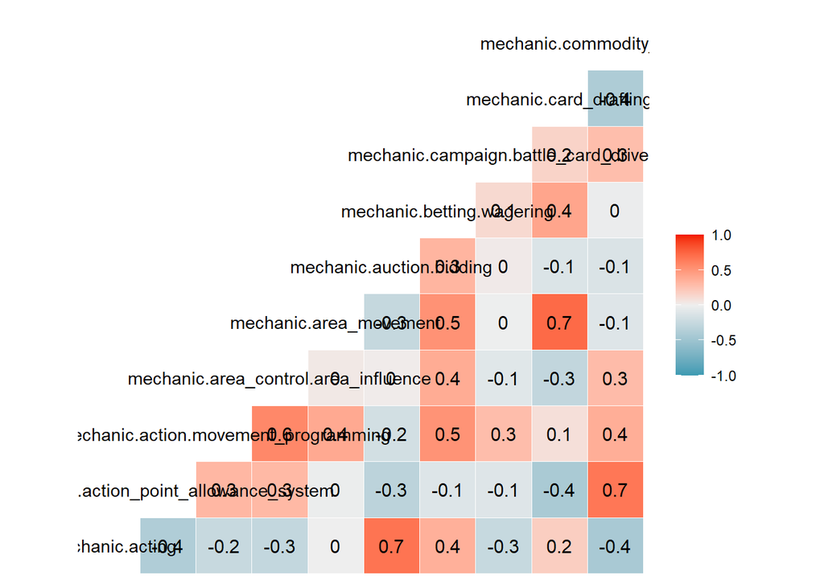

```r
MECH %>%
  select(., 1:10) %>%
  GGally::ggcorr(.,
               palette = "RdBu",
               label = TRUE)
```

# 13 **Optional Challenge Questions:**

## 13.1 *Replacing string patterns*

Sometimes you need to clean up names of variables in a data frame because they are messy, contain funky characters, are too long, etc.

You can do this in base R by assigning the names to be cleaned up names:

`names(the names) <- the cleaned up old names(the names)`

`gsub()` is a function designed to replace a pattern in strings with some other pattern. It takes arguments for the `pattern`, the `replacement` pattern, and the `x` object to search for the pattern.

For example, you can search for “Old” and replace with “New” in a vector. What is returned is the vector containing the replacement(s).

```r
#?gsub
gsub(pattern = "Old", replacement = "New", x = c("New", "Old"))
```

```
## [1] "New" "New"
```

OK, so how might you do this with `dplyr`? The `rename_with()` function will help you in this case. It is a special case of `rename()`, which is usually fine.

But implementing this step is difficult. Here is how you would do it:

`my_data %>%` `rename_with(., ~ gsub("look for this", "replace with this", .x, fixed = T))`

If you want to replace a pattern match with nothing, use an empty string `""`.

Use the example above to:

- select the variables that are mechanics
- remove mechanic from the names
- replace / with _
- replace - space with _
- replace a space with _
- return the new names as a vector

```r
MECH <- GAME_DAT %>%
  select(., starts_with("mechan"))

MECH_CLEANED <- MECH %>%
  rename_with(., ~ tolower(gsub("mechanic", "", .x, fixed = T))) %>%
  # replace / with _
  rename_with(., ~ (gsub("/", "_", .x, fixed = T))) %>%
  # replace - with _
  rename_with(., ~ (gsub("-", "_", .x, fixed = T))) %>%
  # replace " " with _
  rename_with(., ~ (gsub(" ", "_", .x, fixed = T)))
```

## 13.2 *Using `which()` and `%in%` and negation `!`*

For at least one of the questions above, you probably coded a solution that may cause problems if the column index number changes for the variables. This is often a problem with data sets that are not consistent. For example, a client provides you with a data set one week and another week with the variables in different orders. Beware that they may also provide data with names that are different too.

In base R, the `%in%` operator will allow you to determine where x is in y.

```r
"x" %in% "y"    # is string in string
```

```
## [1] FALSE
```

```r
"x" %in% "x"    # is string in string
```

```
## [1] TRUE
```

```r
"X" %in% "x"    # is string in string
```

```
## [1] FALSE
```

```r
tolower(c("x", "X", "t")) %in% "x"  # is element 1, 2, 3 in string
```

```
## [1]  TRUE  TRUE FALSE
```

```r
# note, the reverse query is not the same
"x" %in% tolower(c("x", "X", "t"))
```

```
## [1] TRUE
```

```r
1 %in% c(1,2,3)
```

```
## [1] TRUE
```

```r
TRUE %in% c(TRUE, FALSE)
```

```
## [1] TRUE
```

```r
pets <- c("cat", "dog", "hamster")


"cat" %in% pets
```

```
## [1] TRUE
```

If you want to ask whether x is NOT in y using the `%in%` operator, then you would ask in a different way. Essentially you have to negate your query using an operator that represents a negation.

You basically will ask “Is NOT cat in pets” by using the `!` operator, which indicates logical negation (NOT). If “cat” is in `pets`, then R will return `TRUE` so the negation is `FALSE`. When you use !“cats”, you are sending the query “Are cats NOT in pets”, which will return `FALSE` because the string is in the character vector.

```r
#help("!")

!"cat" %in% pets
```

```
## [1] FALSE
```

For example, there is an object in base R named `LETTERS` which contains the upper-case version of the alphabet. If you want to find out the index position of a particular letter, you can use:

```r
which(LETTERS == "R")
```

```
## [1] 18
```

```r
which(LETTERS == "r")
```

```
## integer(0)
```

And for positions of multiple elements:

```r
which(LETTERS %in% c("A", "Q"))
```

```
## [1]  1 17
```

```r
#or
my_letters <- c("A", "Q")

which(LETTERS %in% my_letters)
```

```
## [1]  1 17
```

Take the following variable names:

- “Response ID”
- “enjoy discovering”,
- “enjoy competing”,
- “theme-Spatial Puzzles”,
- “mechanic-betting/wagering”
- “category-trivia”

First, use `which()` to return the index corresponding to names from the data frame that are in your vector of 6 names. This part may be tricky for you to assemble.

Second, then based on this, select the variables from your data frame by their element position.

The point of this exercise is to have you consider using either element indices or names and switching between them whenever is appropriate. Sometimes passing character objects will cause errors so you can avoid this by referencing the indices associated with the characters.

```r
vars_6 <- c("Response ID", "enjoy discovering",
            "enjoy competing", "theme-Spatial Puzzles",
            "mechanic-betting/wagering", "category-trivia")

GAME_DAT %>%
  select(., which(colnames(.) %in% c(vars_6))) # passes index
```

```
## # A tibble: 38 × 6
##    `Response ID`     `enjoy discovering` enjoy competi…¹ theme…² mecha…³ categ…⁴
##    <chr>                           <dbl>           <dbl>   <dbl>   <dbl>   <dbl>
##  1 R_pfUFKKhv5gVN3DH                   1               1      11       3       1
##  2 R_3hlotx34gc2vRnJ                   1               1      11       1       1
##  3 R_3g5HtZqyn4Vs2EM                   2               1      12       1       1
##  4 R_3j9vVtNAhfEBKoA                   1               2      11       2      NA
##  5 R_27Trar9CSlDgInF                   2               2      11       3       1
##  6 R_3iEaqEcYeuMqCDV                   3               1      11       1       2
##  7 R_1P5VIld1jxFRsCs                   1               1      12       1       1
##  8 R_1RfVyxVokWDVSBX                   1               1      13       1       2
##  9 R_p6LMxbZ9hJiMfXH                   1               1      11       1       1
## 10 R_2qBIzpaEep4lz2H                   2               1      11       1       1
## # … with 28 more rows, and abbreviated variable names ¹`enjoy competing`,
## #   ²`theme-Spatial Puzzles`, ³`mechanic-betting/wagering`, ⁴`category-trivia`
```

**Upload Submission**: Make sure you have named your file correctly, knit it to html (click icon in RStudio) and upload file [here](https://claremontmckenna.app.box.com/f/80863fd8e0f44ec7a95882d9dda8bb91).

```r
message(paste0("knit by ", usr_time))
```

```
## knit by gcook: sun sep 18 16:11:14 2022
```